# Casualties in world war 2

Ida Bolther Holleufer

2023-10-26

Before i can use Rstudio, do i need to tell the program what type of packages i will be using and then do i have to downloaed them

```r
library(tidyverse)
library(dplyr)
```

Now that i have run the packages, can i load the data needed to create a visualisation. Which in this case will be a graph.

```r
casualties <- read_csv2("data/Casualties_of_ww2.csv")
```

```
## ℹ Using "','" as decimal and "'.'" as grouping mark. Use `read_delim()` for more control.
```

```r
casualties
```

```
## # A tibble: 61 × 8
##    Key_id Country   casualties_total casualties_military Population_1939
##     <dbl> <chr>                <dbl>               <dbl>           <dbl>
##  1      1 Albania              30200               30000         1073000
##  2      2 Australia            40500               39800         6968000
##  3      3 Austria             384700              261000         6653000
##  4      4 Belgium              86100               12100         8387000
##  5      5 Brazil                2000                1000        40289000
##  6      6 Bulgaria             25000               22000         6458000
##  7      7 Burma              1000000                2600        16119000
##  8      8 Canada               45400               45400        11267000
##  9      9 China             20000000             4000000       517568000
## 10     10 Cuba                   100                  NA         4235000
## # ℹ 51 more rows
## # ℹ 3 more variables: casualties_percentage <dbl>, continent <chr>,
## #   casualties_100000 <dbl>
```

To create a visualisation will i be using ggplot. ggplot is a system of decleratively creating graphics, based on the data provided. In this case will the data be the uploaded casualties file, that i have created.

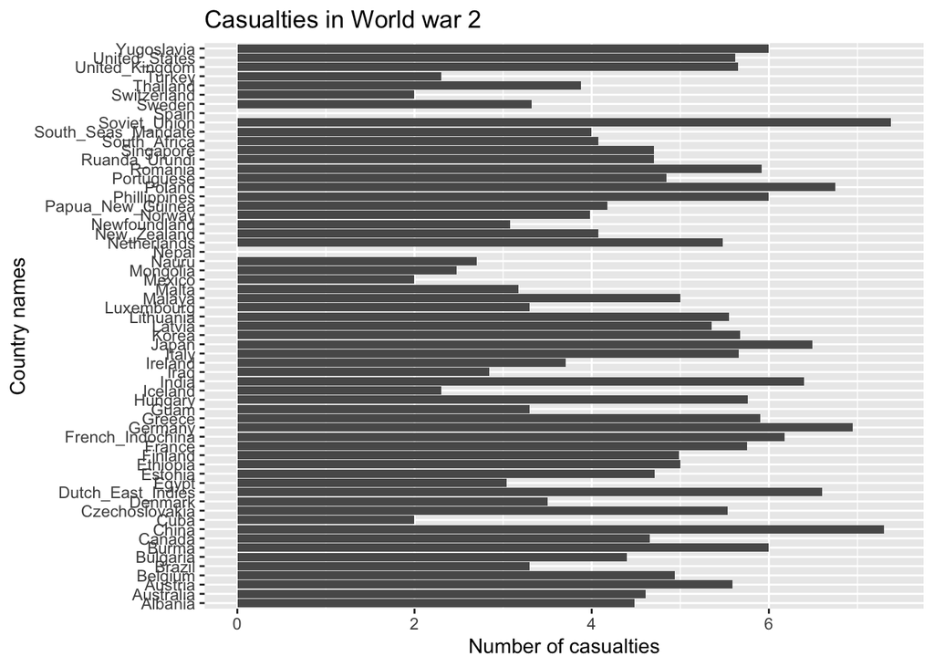

```r
casualties %>%
  ggplot(aes(x = Country, y = log10(casualties_total)))+
  geom_col()+
  theme_classic() %>%
  labs(title = "Casualties in World war 2",
       x = "Country names",
       y = "Number of casualties")+
  coord_flip()
```

```r
ggsave("visualization.png")
```

As it is shown, do i know have a graphic visualisation that shows the different countries compared to each others. But as it is seen, is the numbers and countries really close together, which makes it almost impossible to read.

To make the graphic visualisation easier to read, can i sort the countries by continent. I will start by finding the countries in Europe. This is done by using the code.

```r
casualties_EU <- casualties %>%
  filter(continent == "Europe")
```

Now that i have found which countries there are in Europe, can i use the same code to create a graphic visualisation as before.

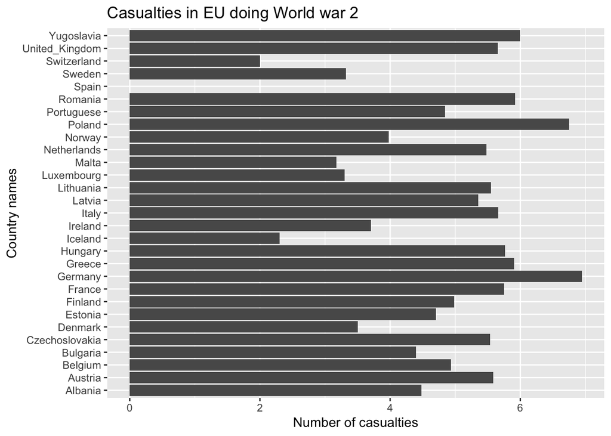

```r
casualties_EU %>%
  ggplot(aes(x = Country, y = log10(casualties_total)))+
  geom_col()+
  theme_classic() %>%
  labs(title = "Casualties in EU doing World war 2",
       x = "Country names",
       y = "Number of casualties")+
 coord_flip()
```

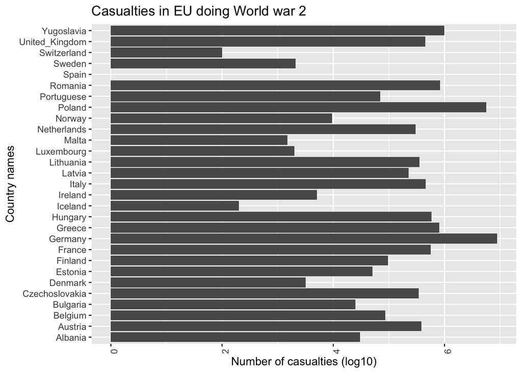

```r
options(scipen=999)

casualties_EU$casualties_total <- gsub("[.]","",casualties_EU$casualties_total)
casualties_EU$casualties_total <- as.numeric(casualties_EU$casualties_total)

casualties_EU %>%
  ggplot(aes(x = Country, y = log10(casualties_total)))+
  geom_col()+
  theme_classic() %>%
  labs(title = "Casualties in EU doing World war 2",
       x = "Country names",
       y = "Number of casualties (log10)")+
  theme(axis.text.x = element_text(angle = 90)) +
 coord_flip()
```

I am using log10 to make the numbers stand closer together. I have visualised to of the numbers, to show what log10 means. 2=10^2 4=10^4

Now will i make the graph easier to read by sorting the countries

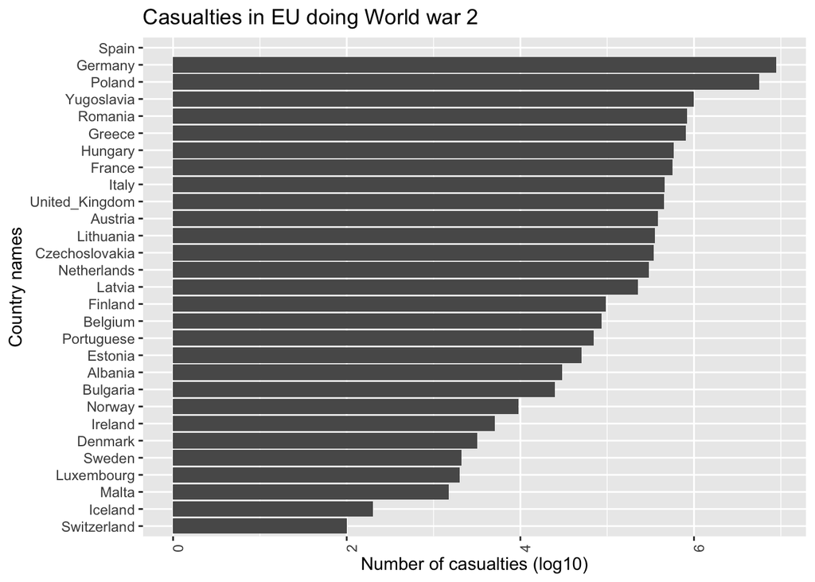

```r
options(scipen=999)

casualties_EU$casualties_total <- gsub("[.]","",casualties_EU$casualties_total)
casualties_EU$casualties_total <- as.numeric(casualties_EU$casualties_total)

ggplot(casualties_EU, aes(x = reorder(Country, casualties_total),  y = log10(casualties_total)))+
  geom_col()+
  theme_classic() %>%
  labs(title = "Casualties in EU doing World war 2",
       x = "Country names",
       y = "Number of casualties (log10)")+
  theme(axis.text.x = element_text(angle = 90)) +
 coord_flip()
```

```r
ggsave("visualization_EU.png")
```

Because the casualties are in numbers (log10) will it be hard to compare the different countries. I estimate that the countries who have a bigger population number also will have a higher death number, then the smaller countries.

I have created a column that shows percentage (Casualties_total / Population_1939) and use this to look at what country lost the most people. But i have also created a column that shows how many people died per. 100.000.

These (percentage and the number of people that died per. 100.000) can be used to compare the countries. I will be using the number of casualties per. 100.000 citizens.

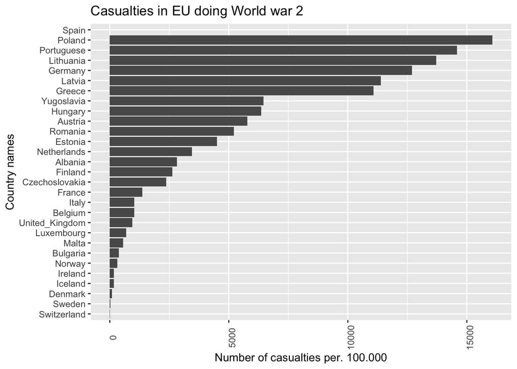

```r
casualties_EU %>%
  ggplot(aes(x = reorder(Country, casualties_100000),  y = casualties_100000))+
  geom_col()+
  theme_classic() %>%
  labs(title = "Casualties in EU doing World war 2",
       x = "Country names",
       y = "Number of casualties per. 100.000")+
  theme(axis.text.x = element_text(angle = 90)) +
 coord_flip()
```

The reason there is no column from Spain, is because the data is missing. It is possible to make Rstudio create the graph without Spain, but i have chosen to keep it.

I can now find the number of casualties per. 100.000 citizens for the other continents by using the code from line 36 to 39 (i will just change the continent) and line 101-112

```r
casualties_Asia <- casualties %>%
  filter(continent == "Asia")
```

The visualization for Asia

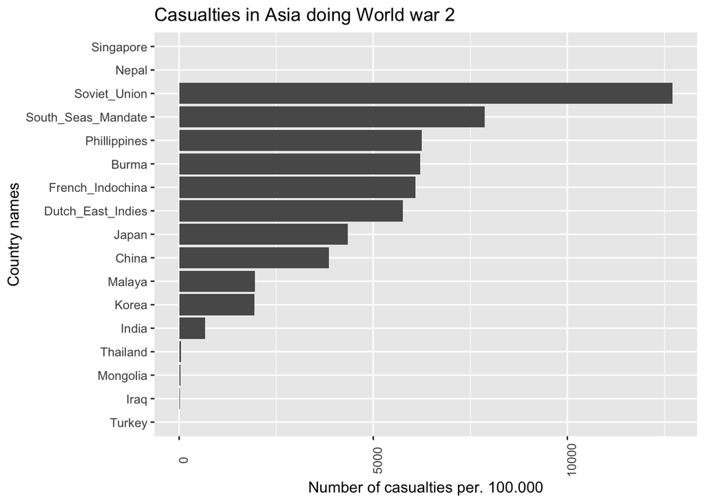

```r
casualties_Asia %>%
  ggplot(aes(x = reorder(Country, casualties_100000),  y = casualties_100000))+
  geom_col()+
  theme_classic() %>%
  labs(title = "Casualties in Asia doing World war 2",
       x = "Country names",
       y = "Number of casualties per. 100.000")+
  theme(axis.text.x = element_text(angle = 90)) +
 coord_flip()
```

Here is also some countries where there is no column from, this is also because of the missing data.

```r
casualties_Oceanien <- casualties %>%
  filter(continent == "Oceanien")
```

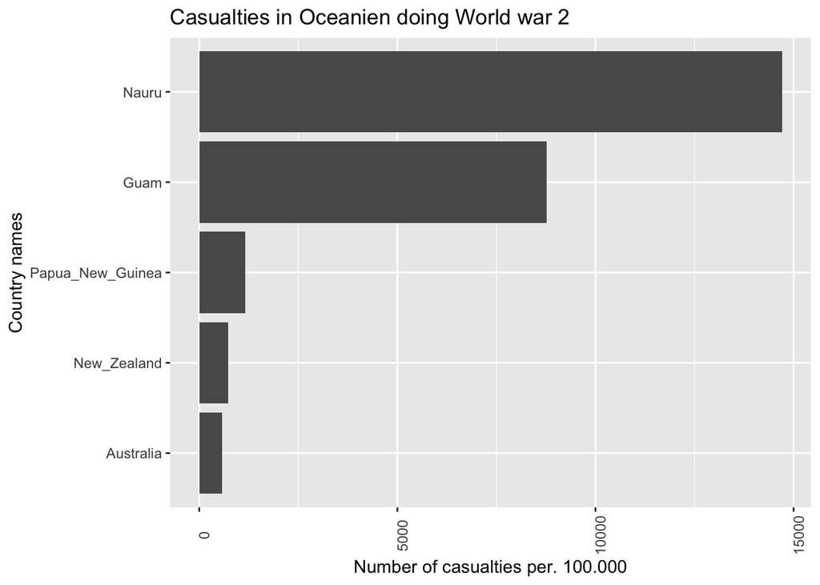

```r
casualties_Oceanien %>%
  ggplot(aes(x = reorder(Country, casualties_100000),  y = casualties_100000))+
  geom_col()+
  theme_classic() %>%
  labs(title = "Casualties in Oceanien doing World war 2",
       x = "Country names",
       y = "Number of casualties per. 100.000")+
  theme(axis.text.x = element_text(angle = 90)) +
 coord_flip()
```

```r
casualties_South_America <- casualties %>%
  filter(continent == "South_America")
```

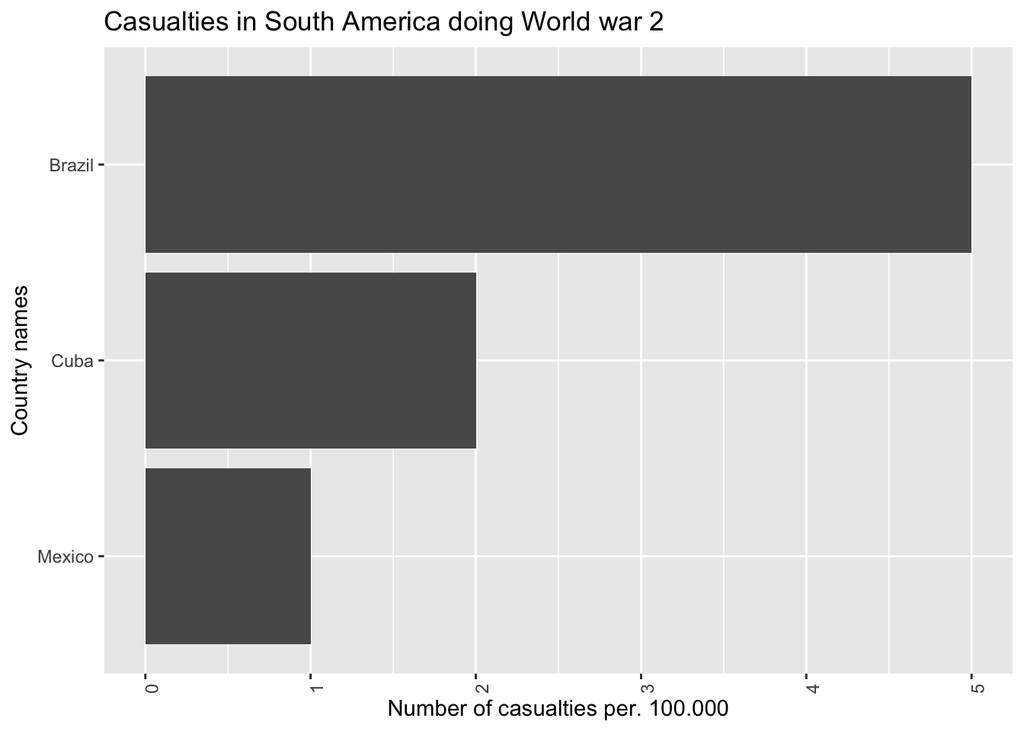

```r
casualties_South_America %>%
  ggplot(aes(x = reorder(Country, casualties_100000),  y = casualties_100000))+
  geom_col()+
  theme_classic() %>%
  labs(title = "Casualties in South America doing World war 2",
       x = "Country names",
       y = "Number of casualties per. 100.000")+
  theme(axis.text.x = element_text(angle = 90)) +
 coord_flip()
```

```r
casualties_North_America <- casualties %>%
  filter(continent == "North_America")
```

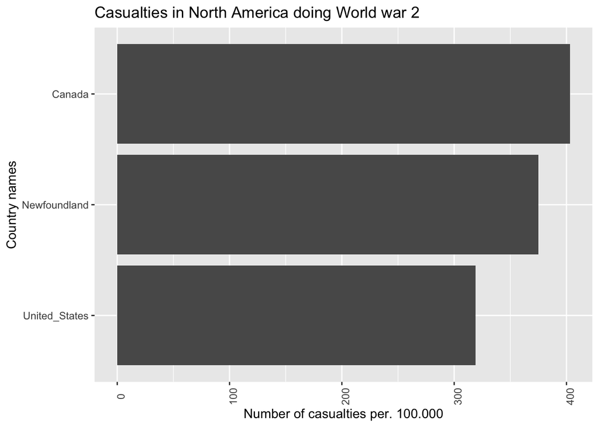

```r
casualties_North_America %>%
  ggplot(aes(x = reorder(Country, casualties_100000),  y = casualties_100000))+
  geom_col()+
  theme_classic() %>%
  labs(title = "Casualties in North America doing World war 2",
       x = "Country names",
       y = "Number of casualties per. 100.000")+
  theme(axis.text.x = element_text(angle = 90)) +
 coord_flip()
```

```r
casualties_Africa <- casualties %>%
  filter(continent == "Africa")
```

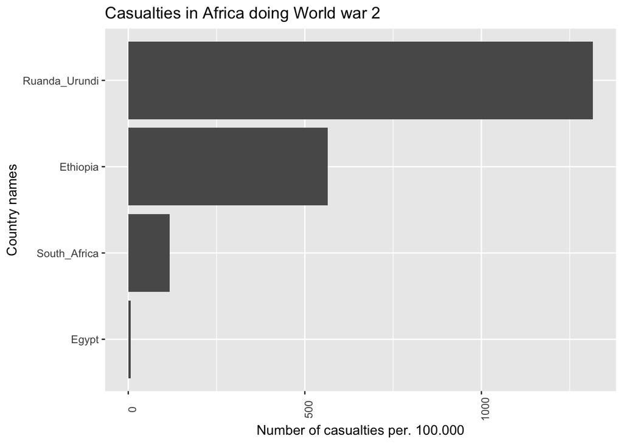

```r
casualties_Africa %>%
  ggplot(aes(x = reorder(Country, casualties_100000),  y = casualties_100000))+
  geom_col()+
  theme_classic() %>%
  labs(title = "Casualties in Africa doing World war 2",
       x = "Country names",
       y = "Number of casualties per. 100.000")+
  theme(axis.text.x = element_text(angle = 90)) +
 coord_flip()
```

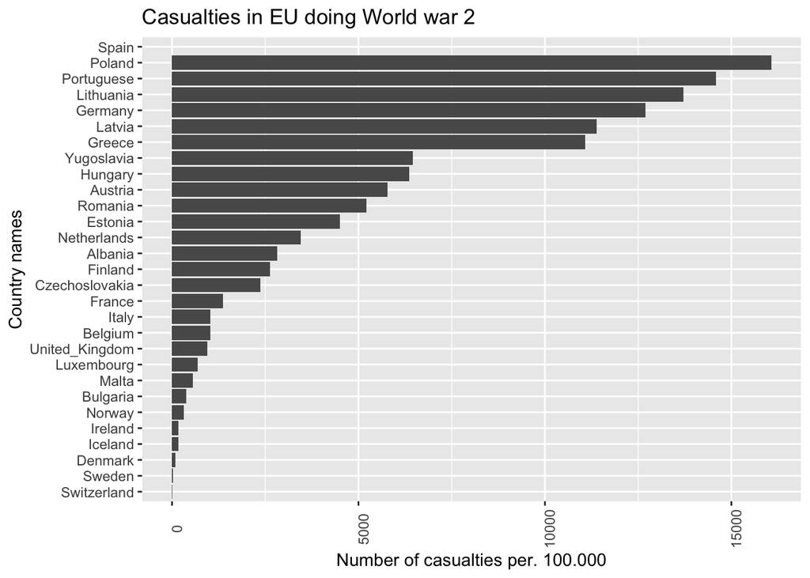

```r
casualties_EU %>%
  ggplot(aes(x = reorder(Country, casualties_100000),  y = casualties_100000))+
  geom_col()+
  theme_classic() %>%
  labs(title = "Casualties in EU doing World war 2",
       x = "Country names",
       y = "Number of casualties per. 100.000")+
  theme(axis.text.x = element_text(angle = 90)) +
 coord_flip()
```

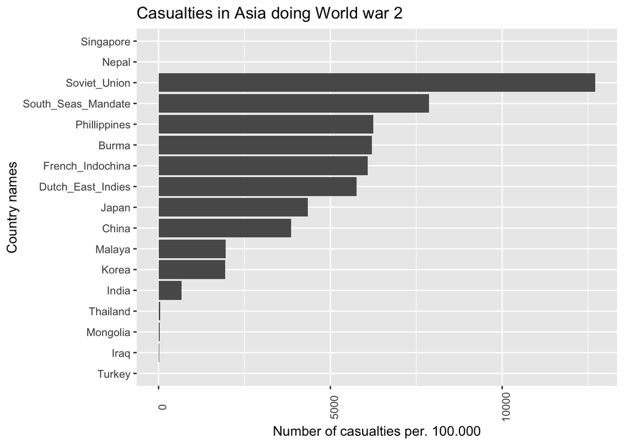

```r
casualties_Asia %>%
  ggplot(aes(x = reorder(Country, casualties_100000),  y = casualties_100000))+
  geom_col()+
  theme_classic() %>%
  labs(title = "Casualties in Asia doing World war 2",
       x = "Country names",
       y = "Number of casualties per. 100.000")+
  theme(axis.text.x = element_text(angle = 90)) +
 coord_flip()
```

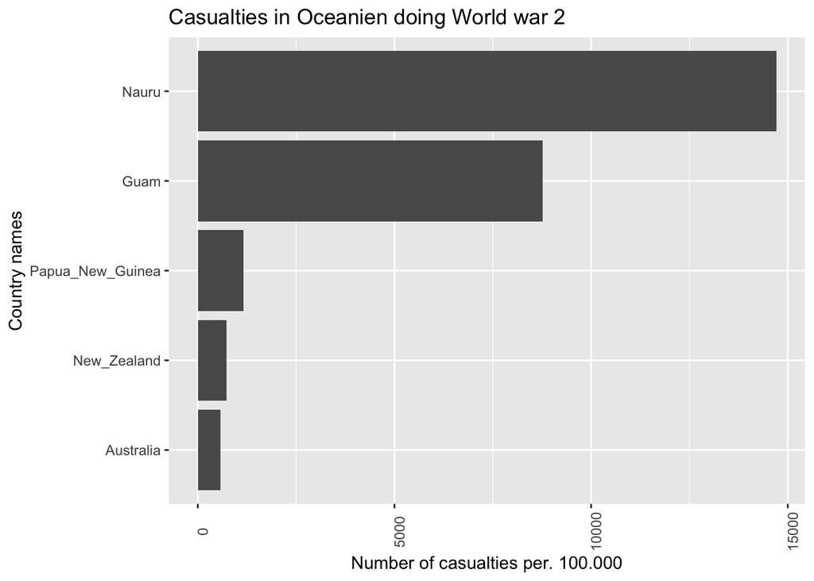

```r
casualties_Oceanien %>%
  ggplot(aes(x = reorder(Country, casualties_100000),  y = casualties_100000))+
  geom_col()+
  theme_classic() %>%
  labs(title = "Casualties in Oceanien doing World war 2",
       x = "Country names",
       y = "Number of casualties per. 100.000")+
  theme(axis.text.x = element_text(angle = 90)) +
 coord_flip()
```

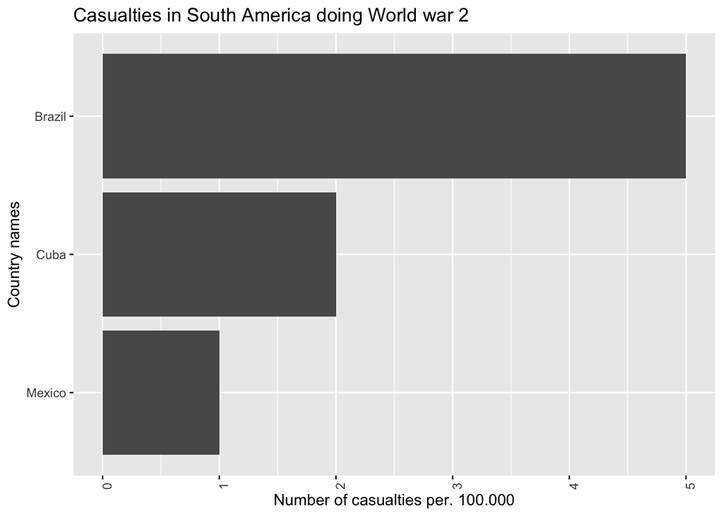

```r
casualties_South_America %>%
  ggplot(aes(x = reorder(Country, casualties_100000),  y = casualties_100000))+
  geom_col()+
  theme_classic() %>%
  labs(title = "Casualties in South America doing World war 2",
       x = "Country names",
       y = "Number of casualties per. 100.000")+
  theme(axis.text.x = element_text(angle = 90)) +
 coord_flip()
```

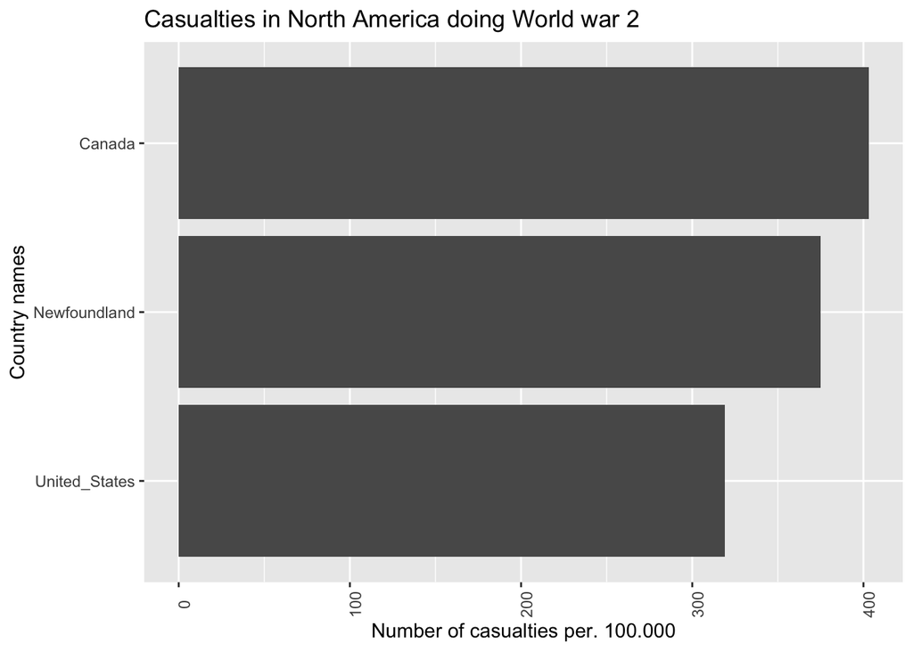

```r
casualties_North_America %>%
  ggplot(aes(x = reorder(Country, casualties_100000),  y = casualties_100000))+
  geom_col()+
  theme_classic() %>%
  labs(title = "Casualties in North America doing World war 2",
       x = "Country names",
       y = "Number of casualties per. 100.000")+
  theme(axis.text.x = element_text(angle = 90)) +
 coord_flip()
```

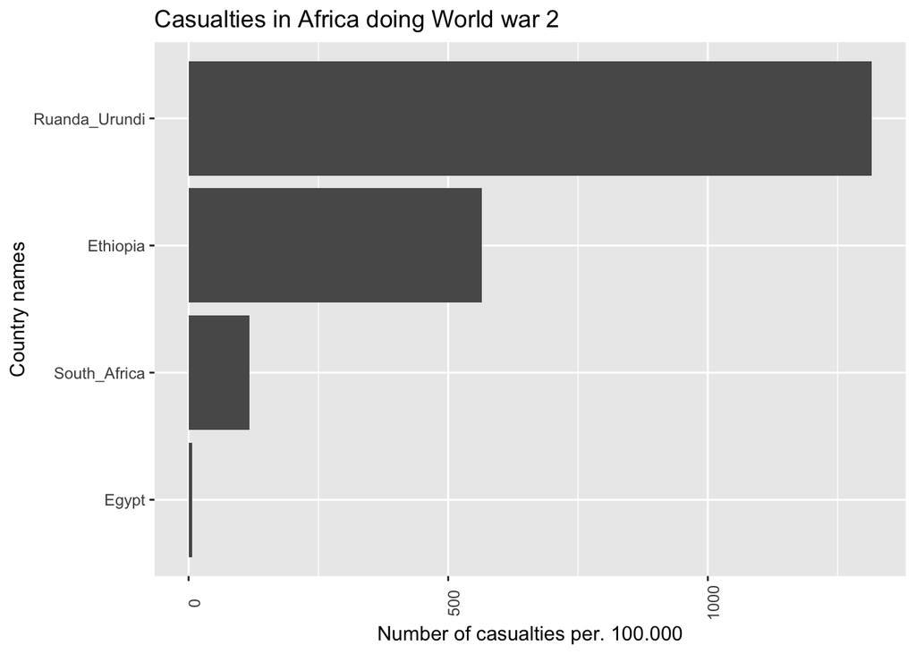

```r
casualties_Africa %>%
  ggplot(aes(x = reorder(Country, casualties_100000),  y = casualties_100000))+
  geom_col()+
  theme_classic() %>%
  labs(title = "Casualties in Africa doing World war 2",
       x = "Country names",
       y = "Number of casualties per. 100.000")+
  theme(axis.text.x = element_text(angle = 90)) +
 coord_flip()
```